# Analyzing Individual BGG Users

Phil Henrickson

2022-01-01

# **mrkayfabe’s** BoardGameGeek Collection

This notebook contains a set of analyses for the selected user’s boardgamegeek collection. The bulk of the analysis is focused on building a user-specific predictive model to predict the games that mrkayfabe is likely to own. This enables to ask questions like, based on the games the user currently owns, what games are a good fit for their collection? What upcoming games are they likely to purchase?

This analysis is based on data from BoardGameGeek that was last updated on **2021-12-20.**

# 1 Collection Overview

We can look at a basic description of the number of games that the user owns, has rated, has previously owned, etc.

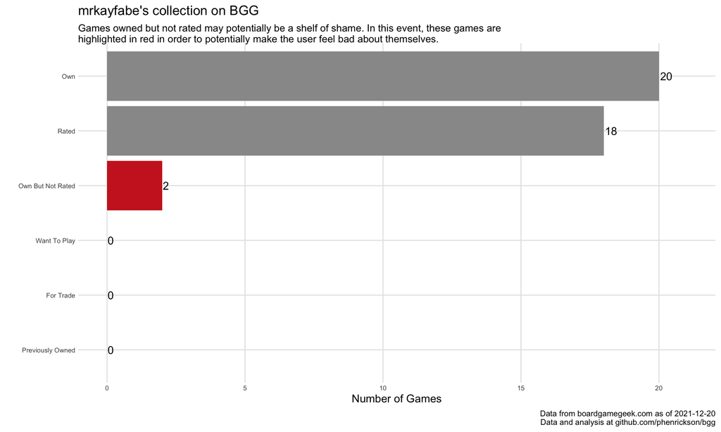

What years has the user owned/rated games from? While we can’t see when a user added or removed a game from their collection, we can look at their collection by the years in which their games were published.

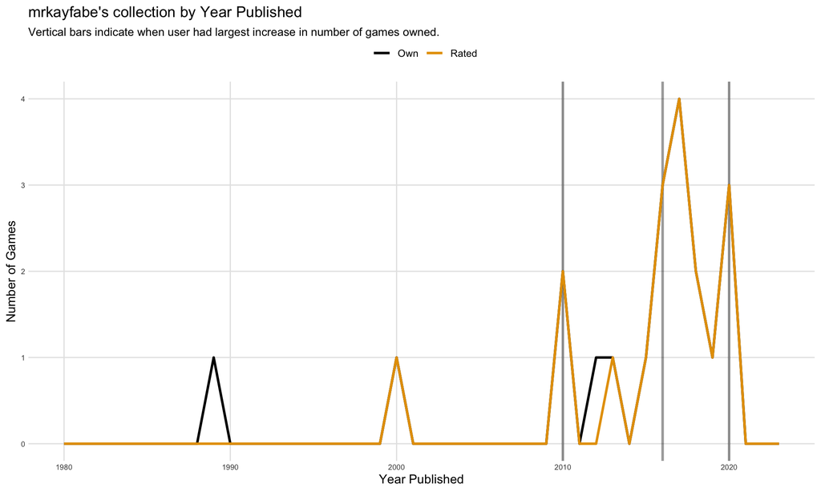

## 1.1 What types of games does mrkayfabe own?

We can look at the most frequent types of categories, mechanics, designers, and artists that appear in a user’s collection.

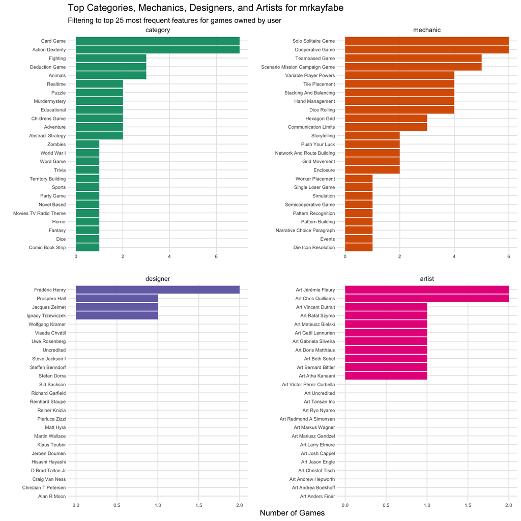

# 2 Modeling **mrkayfabe’s** Collection

| username | dataset | period | games_owned | games_rated | games_played |
| --- | --- | --- | --- | --- | --- |
| mrkayfabe | training | published before 2020 | 17 | 15 | 17 |
| mrkayfabe | test | published 2020 or later | 3 | 3 | 3 |

There are two main (binary) outcomes we will be modeling for the user.

The first, **own** refers to whether the user currently lists a game as owned in their collection. The second, **played** refers to whether the user currently owns, has rated, or previously owned a game. This means the latter will generally have a larger list of games, but may still be a useful category to examine for people who play lots of games without necessarily owning them.

We will train predictive models to learn the probability that the user will own or play individual games based on their features.

## 2.1 Coefficients for mrkayfabe

We can examine coefficients from the trained modes, which are penalized logistic regressions fit to our two main outcomes. Positive values indicate that a feature increases a user’s probabilility of owning/rating a game, while negative values indicate a feature decreases the probability.

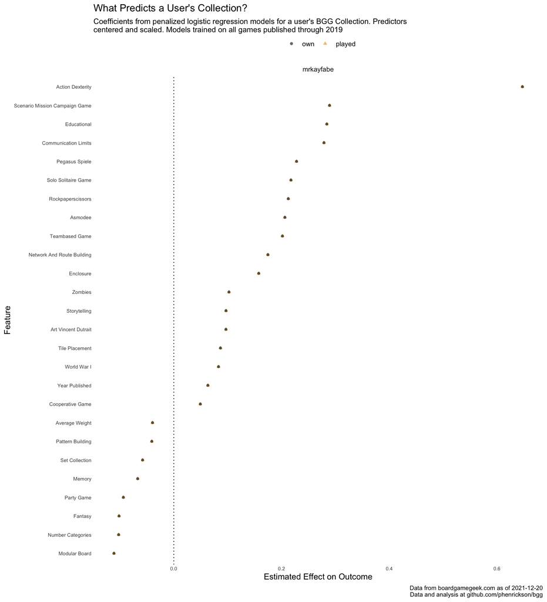

## 2.2 Visualizing Predictors for mrkayfabe’s Collection

Why did the model identify these features? We can make density plots of the important features for predicting whether the user owned a game. Blue indicates the density for games owned by the user, while grey indicates the density for games not owned by the user.

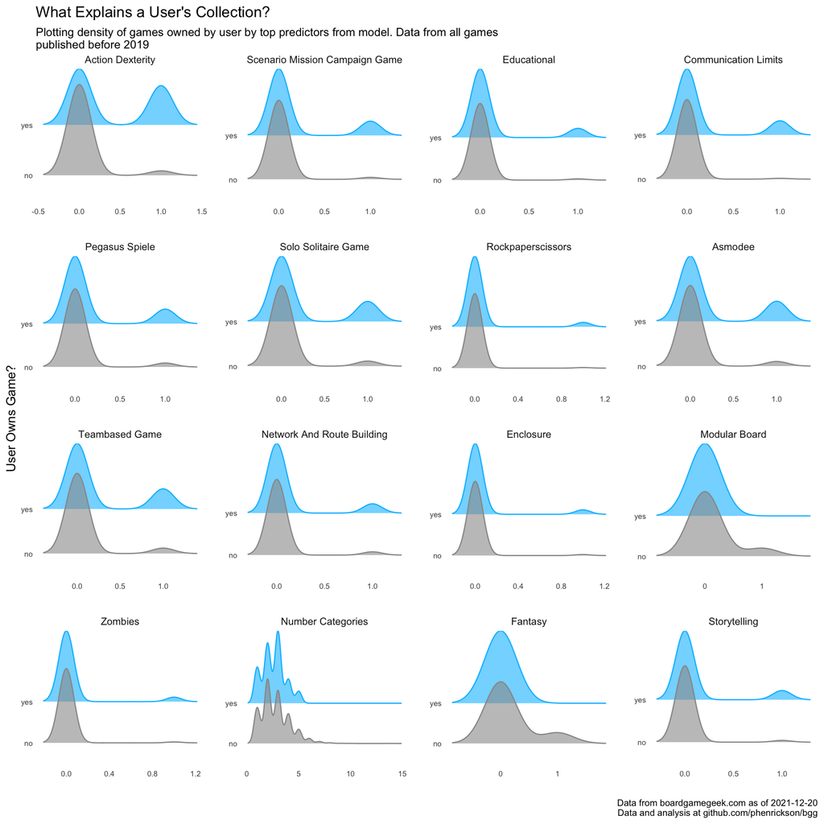

Binary predictors can be difficult to see with this visualization, so we can also directly examine the percentage of games in a user’s collection with a predictor vs the percentage of all games with that predictor.

| username | Feature | % of Games with Feature In_Collection | % of Games with Feature All_Games | Ratio |
| --- | --- | --- | --- | --- |
| mrkayfabe | Communication Limits | 17.6% | 1.0% | 18.2 |
| mrkayfabe | Action Dexterity | 41.2% | 4.7% | 8.7 |
| mrkayfabe | World War I | 5.9% | 0.7% | 8.7 |
| mrkayfabe | Scenario Mission Campaign Game | 17.6% | 2.3% | 7.5 |
| mrkayfabe | Educational | 11.8% | 1.6% | 7.4 |
| mrkayfabe | Rockpaperscissors | 5.9% | 0.8% | 7.4 |
| mrkayfabe | Storytelling | 11.8% | 2.2% | 5.3 |
| mrkayfabe | Enclosure | 5.9% | 1.3% | 4.6 |
| mrkayfabe | Zombies | 5.9% | 1.3% | 4.6 |
| mrkayfabe | Asmodee | 23.5% | 5.4% | 4.4 |
| mrkayfabe | Solo Solitaire Game | 23.5% | 5.9% | 4.0 |
| mrkayfabe | Pegasus Spiele | 17.6% | 4.8% | 3.7 |
| mrkayfabe | Teambased Game | 23.5% | 6.3% | 3.7 |
| mrkayfabe | Cooperative Game | 29.4% | 8.6% | 3.4 |
| mrkayfabe | Network And Route Building | 11.8% | 4.1% | 2.9 |
| mrkayfabe | Fighting | 17.6% | 9.1% | 1.9 |
| mrkayfabe | Tile Placement | 17.6% | 10.5% | 1.7 |
| mrkayfabe | Party Game | 5.9% | 8.5% | 0.7 |
| mrkayfabe | Modular Board | 0.0% | 11.0% | 0.0 |
| mrkayfabe | Fantasy | 0.0% | 14.9% | 0.0 |
| mrkayfabe | Memory | 0.0% | 4.0% | 0.0 |
| mrkayfabe | Set Collection | 0.0% | 17.7% | 0.0 |
| mrkayfabe | Pattern Building | 0.0% | 3.8% | 0.0 |
| mrkayfabe | Player Elimination | 0.0% | 4.1% | 0.0 |
| mrkayfabe | Acting | 0.0% | 1.1% | 0.0 |

# 3 Assess Model’s Performance on Training Set

Before predicting games in upcoming years, we can examine how well the model did and what games it liked in the training set. In this case, we used resampling techniques (cross validation) to ensure that the model had not seen a game before making its predictions.

## 3.1 Separation Plot

An easy way to examine the performance of classification model is to view a separation plot. We plot the predicted probabilities from the model for every game (from resampling) from lowest to highest. We then overlay a blue line for any game that the user does own. A good classifier is one that is able to *separate* the blue (games owned by the user) from the white (games not owned by the user), with most of the blue occurring at the highest probabilities (right side of the chart).

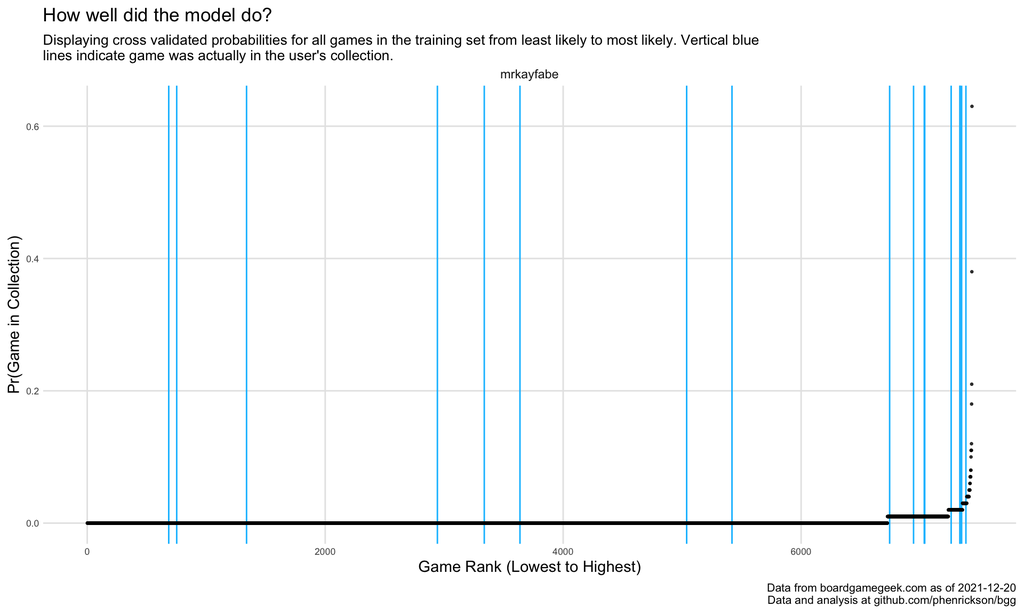

## 3.2 Top Games for **mrkayfabe** from Training Set

We can display this information in table form, displaying the 100 games with the highest probability of ownership, adding a blue line when the user does own the game.

| username | yearpublished | game_id | name | pred_played | pred_own | actual_played | actual_own |
| --- | --- | --- | --- | --- | --- | --- | --- |
| mrkayfabe | 2017 | 174430 | Gloomhaven | 0.63 | 0.63 | 0 | 0 |
| mrkayfabe | 2016 | 198454 | When I Dream | 0.38 | 0.38 | 0 | 0 |
| mrkayfabe | 2016 | 205322 | The Oregon Trail Card Game | 0.21 | 0.21 | 0 | 0 |
| mrkayfabe | 2013 | 145014 | Cardline: Globetrotter | 0.18 | 0.18 | 0 | 0 |
| mrkayfabe | 2017 | 188920 | This War of Mine: The Board Game | 0.12 | 0.12 | 0 | 0 |
| mrkayfabe | 2013 | 133038 | Pathfinder Adventure Card Game: Rise of the Runelords – Base Set | 0.11 | 0.11 | 0 | 0 |
| mrkayfabe | 2016 | 184663 | Covalence: A Molecule Building Game | 0.11 | 0.11 | 0 | 0 |
| mrkayfabe | 2014 | 164265 | Witness | 0.11 | 0.11 | 0 | 0 |
| mrkayfabe | 2014 | 156129 | Deception: Murder in Hong Kong | 0.10 | 0.10 | 0 | 0 |
| mrkayfabe | 2019 | 266304 | MegaCity: Oceania | 0.08 | 0.08 | 0 | 0 |
| mrkayfabe | 2010 | 86415 | Cornerstone Essential | 0.08 | 0.08 | 0 | 0 |
| mrkayfabe | 2019 | 270971 | Era: Medieval Age | 0.07 | 0.07 | 0 | 0 |
| mrkayfabe | 2013 | 145639 | Coconuts | 0.07 | 0.07 | 0 | 0 |
| mrkayfabe | 2016 | 204498 | Match Madness | 0.07 | 0.07 | 0 | 0 |
| mrkayfabe | 2006 | 21654 | Iliad | 0.07 | 0.07 | 0 | 0 |
| mrkayfabe | 2012 | 123096 | Space Cadets | 0.07 | 0.07 | 0 | 0 |
| mrkayfabe | 2018 | 233020 | Fireball Island: The Curse of Vul-Kar | 0.06 | 0.06 | 0 | 0 |
| mrkayfabe | 2018 | 225694 | Decrypto | 0.06 | 0.06 | 0 | 0 |
| mrkayfabe | 2017 | 195421 | Near and Far | 0.05 | 0.05 | 0 | 0 |
| mrkayfabe | 1988 | 4688 | Angola | 0.05 | 0.05 | 0 | 0 |
| mrkayfabe | 2016 | 189160 | Top That! | 0.05 | 0.05 | 0 | 0 |
| mrkayfabe | 2001 | 6420 | Cranium Cadoo | 0.05 | 0.05 | 0 | 0 |
| mrkayfabe | 2019 | 247694 | TEAM3 PINK | 0.05 | 0.05 | 0 | 0 |
| mrkayfabe | 2008 | 56294 | Jungle Speed: Rabbids | 0.05 | 0.05 | 0 | 0 |
| mrkayfabe | 2019 | 218074 | Detective: City of Angels | 0.05 | 0.05 | 0 | 0 |
| mrkayfabe | 2019 | 266179 | Space Gate Odyssey | 0.04 | 0.04 | 0 | 0 |
| mrkayfabe | 2019 | 281946 | Aftermath | 0.04 | 0.04 | 0 | 0 |
| mrkayfabe | 2011 | 98122 | Monster Trap | 0.04 | 0.04 | 0 | 0 |
| mrkayfabe | 1999 | 1353 | Time's Up! | 0.04 | 0.04 | 0 | 0 |
| mrkayfabe | 1972 | 1692 | Spoons | 0.04 | 0.04 | 0 | 0 |

[output cut: 70 more lines]

We can also more formally assess how well the model did in resampling by looking at the area under the receiver operating characteristic. A perfect model would receive a score of 1, while a model that cannot predict the outcome will default to a score of 0.5. The extent to which something is a *good* score depends on the setting, but generally anything in the .8 to .9 range is very good while the .7 to .8 range is perfectly acceptable.

| username | outcome_type | .metric | .estimator | .estimate |
| --- | --- | --- | --- | --- |
| mrkayfabe | own | roc_auc | binary | 0.863 |
| mrkayfabe | played | roc_auc | binary | 0.863 |

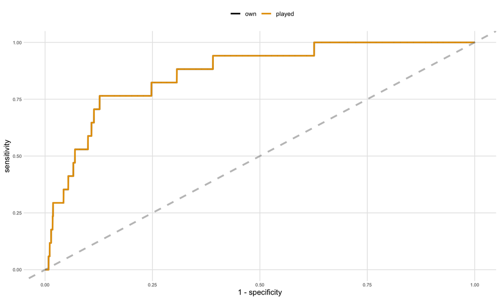

Another way to think about the model performance is to view its lift, or its ability to detect the positive outcomes over that of a null model. High lift indicates the model can much more quickly find all of the positive outcomes (in this case, games owned or played by the user), while a model with no lift is no better than random guessing.

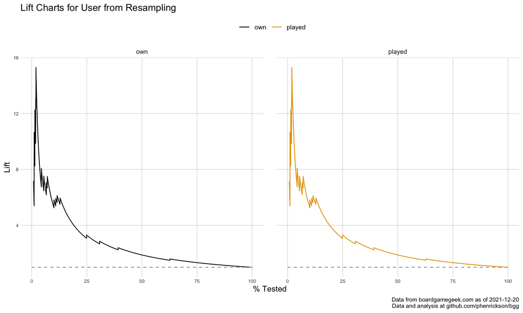

## 3.3 Most and Least Likely Games

What games does the model think mrkayfabe is **most likely to own** that are **not** in their collection?

| username | yearpublished | game_id | name | pred_own | actual_own |
| --- | --- | --- | --- | --- | --- |
| mrkayfabe | 2017 | 174430 | Gloomhaven | 0.63 | 0 |
| mrkayfabe | 2016 | 198454 | When I Dream | 0.38 | 0 |
| mrkayfabe | 2016 | 205322 | The Oregon Trail Card Game | 0.21 | 0 |
| mrkayfabe | 2013 | 145014 | Cardline: Globetrotter | 0.18 | 0 |
| mrkayfabe | 2017 | 188920 | This War of Mine: The Board Game | 0.12 | 0 |

What games does the model think mrkayfabe is **least likely to own** that **are** in their collection?

| username | yearpublished | game_id | name | pred_own | actual_own |
| --- | --- | --- | --- | --- | --- |
| mrkayfabe | 2017 | 175324 | Fog of Love | 0 | 1 |
| mrkayfabe | 2000 | 2655 | Hive | 0 | 1 |
| mrkayfabe | 2018 | 239188 | Chronicles of Crime | 0 | 1 |
| mrkayfabe | 2012 | 121921 | Robinson Crusoe: Adventures on the Cursed Island | 0 | 1 |
| mrkayfabe | 2016 | 191925 | Bandido | 0 | 1 |

## 3.4 Top Games by Year

Top 25 games most likely to be owned by the user in each year, highlighting in blue the games that the user has owned/played.

| rank | 2011 | 2012 | 2013 | 2014 | 2015 | 2016 | 2017 | 2018 | 2019 |
| --- | --- | --- | --- | --- | --- | --- | --- | --- | --- |
| 1 | Monster Trap | Space Cadets | Cardline: Globetrotter | Witness | Codenames | When I Dream | Gloomhaven | Fireball Island: The Curse of Vul-Kar | MegaCity: Oceania |
| 2 | Timeline: Discoveries | Zombicide | Pathfinder Adventure Card Game: Rise of the Runelords – Base Set | Deception: Murder in Hong Kong | In a Bind | The Oregon Trail Card Game | This War of Mine: The Board Game | Decrypto | Era: Medieval Age |
| 3 | Rory's Story Cubes: Voyages | Lift it! | Coconuts | Timeline: American History | Grimslingers | Covalence: A Molecule Building Game | Near and Far | Catacombs Conquest | TEAM3 PINK |
| 4 | Animal Upon Animal: Small and Yet Great! | Escape: The Curse of the Temple | Cappuccino | Spurs: A Tale in the Old West | Flick 'em Up! | Match Madness | Set & Match | Get Packing | Detective: City of Angels |
| 5 | Tragedy Looper | Fantastiqa: The Rucksack Edition | Concept | Doodle Quest | The Grizzled | Top That! | Dr. Microbe | First Contact | Space Gate Odyssey |
| 6 | Disney Pixar Cars 2 Sorry Sliders: World Grand Prix Race Edition | Spectaculum | Tajemnicze Domostwo | Ninja Taisen | Mysterium | Codenames: Pictures | Flick 'em Up!: Dead of Winter | Timeline: Classic | Aftermath |
| 7 | Yomi | Baobab | Disc Duelers | Dragon Punch | ...and then, we held hands. | Codenames: Deep Undercover | Meeple Circus | Detective: A Modern Crime Board Game | Middara: Unintentional Malum – Act 1 |
| 8 | Ascending Empires | Suspend | Carnival Zombie | Bellz! | Kitty Paw | Agricola (Revised Edition) | Codenames: Duet | The City of Kings | Tiny Epic Mechs |
| 9 | The Ares Project | Mini Curling Game | Terror in Meeple City | [redacted] | Spinderella | HMS Dolores | Flip Ships | Menara | TEAM3 GREEN |
| 10 | Coney Island | Timeline | Bugs in the Kitchen | Gloobz | Feelinks | Virus | A Tale of Pirates | The Grizzled: Armistice Edition | One Key |
| 11 | Mage Knight Board Game | Cardline: Animals | Castle Crush! | Wir sind das Volk! | Timeline: Star Wars | Mythos Tales | Zoo Ball | Fuji | Bumúntú |
| 12 | Takenoko | Timeline: General Interest | Ghost Blitz: 5 to 12 | Coconuts Duo | Cat Tower | Doctor Panic | Queendomino | SEAL Team Flix | The Crew: The Quest for Planet Nine |
| 13 | Vintage | Spot it! 1,2,3 | Timeline: Music & Cinema | Speed Cups² | Catacombs (Third Edition) | Aventuria: Adventure Card Game | Fireworks | Belratti | Slide Quest |
| 14 | Angry Birds: Knock on Wood | Boom Boom Balloon | Luchador! Mexican Wrestling Dice | KLASK | The Game | Mondrian: The Dice Game | Go Go Gelato! | Maki Stack | Flick of Faith |
| 15 | Animal Upon Animal: Crest Climbers | Strike | Jungle Speed: Safari | Lagoon: Land of Druids | FUSE | Assembly | BONK | TOKYO METRO | Valley of the Vikings |
| 16 | Munchkin Zombies | Morels | The Ravens of Thri Sahashri | DungeonQuest Revised Edition | Daxu | Kung Fu Zoo | The 7th Continent | Adventure Island | Medium |
| 17 | The Walking Dead: The Board Game | Rock Me Archimedes | Cube Quest | Run, Fight, or Die! | Raptor | Sherlock Holmes Consulting Detective: Jack the Ripper & West End Adventures | Magic Maze | Skies Above the Reich | Similo |
| 18 | Dungeon Fighter | Legends of Andor | Dawn of the Zeds (Second edition) | JamSumo | Brick Party | Garbage Day! | Codenames: Disney – Family Edition | Crystal Clans | Bees: The Secret Kingdom |
| 19 | Flash Point: Fire Rescue | Kingdom of Solomon | Mini Mölkky | Pixel Glory | Wonky | Fold-it | Muse | Fort Sumter: The Secession Crisis, 1860-61 | Men at Work |
| 20 | Dr. Shark | Don't Rock the Boat | Jenga: Tetris | Yomi (Second Edition) | Yeti in My Spaghetti | Tokyo Highway | Yogi | Critical Mass: Raijin vs Archon | Peloponnesian War |
| 21 | Cheating Moth | Riff Raff | Theseus: The Dark Orbit | This Town Ain't Big Enough for the 2-4 of Us | Elysium | 13 Days: The Cuban Missile Crisis | Catch the Moon | Critical Mass: Patriot vs Iron Curtain | Naga Raja |
| 22 | Pharaoh Code | Freedom: The Underground Railroad | 7 Days of Westerplatte | Splash! | Argonauts | High Treason: The Trial of Louis Riel | Sticky Chameleons | Warhammer 40,000: Heroes of Black Reach | Choose Your Own Adventure: War with the Evil Power Master |
| 23 | Rhino Hero | Tier auf Tier: Jetzt geht's rund! | Bauhaus | Spyfall | The King Is Dead | Sola Fide: The Reformation | Pathogenesis | Codenames: Harry Potter | DC Deck-Building Game: Rebirth |
| 24 | Angry Birds: Card Game | Ghost Blitz 2 | The King of Frontier | Loopin' Chewie | Maze Racers | Star Trek: The Dice Game | Untold: Adventures Await | Choose Your Own Adventure: House of Danger | God of War: The Card Game |
| 25 | Sticky Stickz | Hoplomachus: The Lost Cities | The Phantom Society | Trekking the National Parks | Push a Monster | V-Sabotage | Raxxon | Stuffed Fables | Tiny Epic Tactics |

## 3.5 Interactive Predictions from Resampling

Interactive table for predictions from resampling.

|  | username | yearpublished | rank | game_id | name | pred_played | pred_own | actual_played | actual_own |
| --- | --- | --- | --- | --- | --- | --- | --- | --- | --- |
| 1 | mrkayfabe | 1900 | 108 | 521 | Crokinole | 0.02 | 0.02 | 0 | 0 |
| 2 | mrkayfabe | 1900 | 204 | 5546 | Marbles | 0.01 | 0.01 | 0 | 0 |
| 3 | mrkayfabe | 1900 | 356 | 5071 | Sjoelen | 0.01 | 0.01 | 0 | 0 |
| 4 | mrkayfabe | 1900 | 584 | 2386 | Chinese Checkers | 0.01 | 0.01 | 0 | 0 |
| 5 | mrkayfabe | 1900 | 724 | 11901 | Tic-Tac-Toe | 0 | 0 | 0 | 0 |
| 6 | mrkayfabe | 1900 | 773 | 188 | Go | 0 | 0 | 0 | 0 |
| 7 | mrkayfabe | 1900 | 883 | 171 | Chess | 0 | 0 | 0 | 0 |
| 8 | mrkayfabe | 1900 | 894 | 2065 | Shogi | 0 | 0 | 0 | 0 |
| 9 | mrkayfabe | 1900 | 896 | 2393 | Xiangqi | 0 | 0 | 0 | 0 |
| 10 | mrkayfabe | 1900 | 1125 | 26952 | International Checkers | 0 | 0 | 0 | 0 |

[output cut: 7426 more lines]

# 4 Validating the Model on 2020

How well did a model trained on a user’s collection through 2019 perform in predicting games for the user from 2020?

| username | outcome_type | yearpublished | .metric | .estimator | .estimate |
| --- | --- | --- | --- | --- | --- |
| mrkayfabe | own | 2020 | roc_auc | binary | 0.689 |
| mrkayfabe | played | 2020 | roc_auc | binary | 0.689 |

Table of top 25 games from 2020, highlighting games that the user owns.

| username | yearpublished | game_id | name | pred_own | pred_played | actual_own | actual_played |
| --- | --- | --- | --- | --- | --- | --- | --- |
| mrkayfabe | 2020 | 291457 | Gloomhaven: Jaws of the Lion | 0.25 | 0.25 | 0 | 0 |
| mrkayfabe | 2020 | 296517 | Contact: Signals from Outer Space | 0.20 | 0.20 | 0 | 0 |
| mrkayfabe | 2020 | 321711 | My Very First Games: Rhino Hero Junior | 0.15 | 0.15 | 0 | 0 |
| mrkayfabe | 2020 | 296626 | Sonora | 0.10 | 0.10 | 0 | 0 |
| mrkayfabe | 2020 | 297735 | Disciple Detective | 0.10 | 0.10 | 0 | 0 |
| mrkayfabe | 2020 | 313008 | Apollo: A Game Inspired by NASA Moon Missions | 0.09 | 0.09 | 0 | 0 |
| mrkayfabe | 2020 | 318977 | MicroMacro: Crime City | 0.09 | 0.09 | 1 | 1 |
| mrkayfabe | 2020 | 262939 | Far Away | 0.05 | 0.05 | 0 | 0 |
| mrkayfabe | 2020 | 275032 | Ghost Adventure | 0.05 | 0.05 | 0 | 0 |
| mrkayfabe | 2020 | 273092 | Crumbs | 0.04 | 0.04 | 0 | 0 |
| mrkayfabe | 2020 | 283155 | Calico | 0.04 | 0.04 | 1 | 1 |
| mrkayfabe | 2020 | 284217 | Rush M.D. | 0.04 | 0.04 | 0 | 0 |
| mrkayfabe | 2020 | 288513 | Tranquility | 0.04 | 0.04 | 0 | 0 |
| mrkayfabe | 2020 | 301767 | Mysterium Park | 0.04 | 0.04 | 0 | 0 |
| mrkayfabe | 2020 | 269403 | LOTS: A Competitive Tower Building Game | 0.03 | 0.03 | 0 | 0 |
| mrkayfabe | 2020 | 295486 | My City | 0.03 | 0.03 | 0 | 0 |
| mrkayfabe | 2020 | 255635 | Pitch Out | 0.02 | 0.02 | 0 | 0 |
| mrkayfabe | 2020 | 268952 | Crazy Tower | 0.02 | 0.02 | 0 | 0 |
| mrkayfabe | 2020 | 276205 | Philosophia: Dare to be Wise | 0.02 | 0.02 | 0 | 0 |
| mrkayfabe | 2020 | 296498 | 10 Dice | 0.02 | 0.02 | 0 | 0 |
| mrkayfabe | 2020 | 306687 | Get Out of Colditz: The Card Game | 0.02 | 0.02 | 0 | 0 |
| mrkayfabe | 2020 | 314397 | In the Palm of Your Hand | 0.02 | 0.02 | 0 | 0 |
| mrkayfabe | 2020 | 315954 | Hunt A Killer: Death at the Dive Bar | 0.02 | 0.02 | 0 | 0 |
| mrkayfabe | 2020 | 319966 | The King Is Dead: Second Edition | 0.02 | 0.02 | 0 | 0 |
| mrkayfabe | 2020 | 321539 | A Game of Cat & Mouth | 0.02 | 0.02 | 0 | 0 |

# 5 Predicting Upcoming Games (2020 and On) for **mrkayfabe**

Examine the top games for the test set.

| username | yearpublished | game_id | name | rank | own | played |
| --- | --- | --- | --- | --- | --- | --- |
| mrkayfabe | 2020 | 291457 | Gloomhaven: Jaws of the Lion | 1 | 0.25 | 0.25 |
| mrkayfabe | 2020 | 296517 | Contact: Signals from Outer Space | 2 | 0.20 | 0.20 |
| mrkayfabe | 2020 | 321711 | My Very First Games: Rhino Hero Junior | 3 | 0.15 | 0.15 |
| mrkayfabe | 2020 | 297735 | Disciple Detective | 4 | 0.10 | 0.10 |
| mrkayfabe | 2020 | 296626 | Sonora | 5 | 0.10 | 0.10 |
| mrkayfabe | 2020 | 313008 | Apollo: A Game Inspired by NASA Moon Missions | 6 | 0.09 | 0.09 |
| mrkayfabe | 2020 | 318977 | MicroMacro: Crime City | 7 | 0.09 | 0.09 |
| mrkayfabe | 2020 | 275032 | Ghost Adventure | 8 | 0.05 | 0.05 |
| mrkayfabe | 2020 | 262939 | Far Away | 9 | 0.05 | 0.05 |
| mrkayfabe | 2020 | 283155 | Calico | 10 | 0.04 | 0.04 |
| mrkayfabe | 2020 | 284217 | Rush M.D. | 11 | 0.04 | 0.04 |
| mrkayfabe | 2020 | 273092 | Crumbs | 12 | 0.04 | 0.04 |
| mrkayfabe | 2020 | 301767 | Mysterium Park | 13 | 0.04 | 0.04 |
| mrkayfabe | 2020 | 288513 | Tranquility | 14 | 0.04 | 0.04 |
| mrkayfabe | 2020 | 269403 | LOTS: A Competitive Tower Building Game | 15 | 0.03 | 0.03 |
| mrkayfabe | 2020 | 295486 | My City | 16 | 0.03 | 0.03 |
| mrkayfabe | 2020 | 321539 | A Game of Cat & Mouth | 17 | 0.02 | 0.02 |
| mrkayfabe | 2020 | 255635 | Pitch Out | 18 | 0.02 | 0.02 |
| mrkayfabe | 2020 | 296498 | 10 Dice | 19 | 0.02 | 0.02 |
| mrkayfabe | 2020 | 325555 | Cantaloop: Book 1 – Breaking into Prison | 20 | 0.02 | 0.02 |
| mrkayfabe | 2020 | 332782 | Cantaloop: Prequel | 21 | 0.02 | 0.02 |
| mrkayfabe | 2020 | 276205 | Philosophia: Dare to be Wise | 22 | 0.02 | 0.02 |
| mrkayfabe | 2020 | 306687 | Get Out of Colditz: The Card Game | 23 | 0.02 | 0.02 |
| mrkayfabe | 2020 | 268952 | Crazy Tower | 24 | 0.02 | 0.02 |
| mrkayfabe | 2020 | 319966 | The King Is Dead: Second Edition | 25 | 0.02 | 0.02 |
| mrkayfabe | 2021 | 338834 | MicroMacro: Crime City – Full House | 1 | 0.16 | 0.16 |
| mrkayfabe | 2021 | 324856 | The Crew: Mission Deep Sea | 2 | 0.09 | 0.09 |
| mrkayfabe | 2021 | 293665 | Ensemble | 3 | 0.07 | 0.07 |
| mrkayfabe | 2021 | 299255 | Vienna Connection | 4 | 0.06 | 0.06 |
| mrkayfabe | 2021 | 326804 | Rorschach | 5 | 0.05 | 0.05 |
| mrkayfabe | 2021 | 342021 | Space Invaders | 6 | 0.04 | 0.04 |
| mrkayfabe | 2021 | 293835 | Oltréé | 7 | 0.04 | 0.04 |
| mrkayfabe | 2021 | 299933 | Dice Flick | 8 | 0.04 | 0.04 |
| mrkayfabe | 2021 | 289565 | Hunted: Mining Colony 415 | 9 | 0.03 | 0.03 |
| mrkayfabe | 2021 | 310789 | Catapult Feud | 10 | 0.02 | 0.02 |
| mrkayfabe | 2021 | 319579 | Crash Octopus | 11 | 0.02 | 0.02 |
| mrkayfabe | 2021 | 312182 | JamSumo (Second Edition) | 12 | 0.02 | 0.02 |
| mrkayfabe | 2021 | 314421 | The Fuzzies | 13 | 0.02 | 0.02 |
| mrkayfabe | 2021 | 334543 | Rolling Dice | 14 | 0.02 | 0.02 |
| mrkayfabe | 2021 | 293207 | Eila and Something Shiny | 15 | 0.02 | 0.02 |
| mrkayfabe | 2021 | 340909 | Gloomholdin' | 16 | 0.02 | 0.02 |
| mrkayfabe | 2021 | 282700 | LOOP: Life of Ordinary People | 17 | 0.02 | 0.02 |
| mrkayfabe | 2021 | 347137 | Chronicles of Avel | 18 | 0.02 | 0.02 |
| mrkayfabe | 2021 | 348955 | Rock Paper Scissors: Deluxe Edition | 19 | 0.02 | 0.02 |
| mrkayfabe | 2021 | 260789 | Assassin's Creed: Brotherhood of Venice | 20 | 0.02 | 0.02 |
| mrkayfabe | 2021 | 315624 | World Changers | 21 | 0.02 | 0.02 |
| mrkayfabe | 2021 | 302461 | Intrepid | 22 | 0.02 | 0.02 |
| mrkayfabe | 2021 | 340288 | Kids Chronicles: Quest for the Moon Stones | 23 | 0.02 | 0.02 |
| mrkayfabe | 2021 | 336929 | Land vs Sea | 24 | 0.02 | 0.02 |
| mrkayfabe | 2021 | 342019 | 60 Second City | 25 | 0.02 | 0.02 |
| mrkayfabe | 2022 | 295770 | Frosthaven | 1 | 0.09 | 0.09 |
| mrkayfabe | 2022 | 293547 | Reload | 2 | 0.02 | 0.02 |
| mrkayfabe | 2022 | 340325 | Vagrantsong | 3 | 0.02 | 0.02 |
| mrkayfabe | 2022 | 311988 | Frostpunk: The Board Game | 4 | 0.02 | 0.02 |
| mrkayfabe | 2022 | 332686 | John Company: Second Edition | 5 | 0.01 | 0.01 |
| mrkayfabe | 2022 | 299106 | Fractal: Beyond the Void | 6 | 0.01 | 0.01 |
| mrkayfabe | 2022 | 321608 | Hegemony: Lead Your Class to Victory | 7 | 0.01 | 0.01 |
| mrkayfabe | 2022 | 284118 | Mechanical Beast | 8 | 0.01 | 0.01 |
| mrkayfabe | 2022 | 270871 | Agemonia | 9 | 0.01 | 0.01 |
| mrkayfabe | 2022 | 325494 | ISS Vanguard | 10 | 0.01 | 0.01 |
| mrkayfabe | 2022 | 317321 | Darkest Dungeon: The Board Game | 11 | 0.01 | 0.01 |
| mrkayfabe | 2022 | 342444 | Black Rose Wars: Rebirth | 12 | 0.01 | 0.01 |
| mrkayfabe | 2022 | 256680 | Return to Dark Tower | 13 | 0.01 | 0.01 |
| mrkayfabe | 2022 | 303731 | Primal: The Awakening | 14 | 0.01 | 0.01 |
| mrkayfabe | 2022 | 317511 | Tindaya | 15 | 0.01 | 0.01 |
| mrkayfabe | 2022 | 319807 | Shogun no Katana | 16 | 0.01 | 0.01 |
| mrkayfabe | 2022 | 334065 | Verdant | 17 | 0.01 | 0.01 |
| mrkayfabe | 2022 | 320718 | Hidden Leaders | 18 | 0.00 | 0.00 |
| mrkayfabe | 2022 | 281647 | Stellaris: Infinite Legacy | 19 | 0.00 | 0.00 |
| mrkayfabe | 2022 | 336986 | Flamecraft | 20 | 0.00 | 0.00 |
| mrkayfabe | 2022 | 254632 | Hyperspace | 21 | 0.00 | 0.00 |
| mrkayfabe | 2022 | 339592 | Sheep in Disguise | 22 | 0.00 | 0.00 |
| mrkayfabe | 2022 | 319910 | Pagan: Fate of Roanoke | 23 | 0.00 | 0.00 |
| mrkayfabe | 2022 | 274124 | Northgard: Uncharted Lands | 24 | 0.00 | 0.00 |
| mrkayfabe | 2022 | 318450 | Bios: Mesofauna | 25 | 0.00 | 0.00 |

## 5.1 Interactive Table for Upcoming Games 2020 and On

|  | username | yearpublished | game_id | name | rank | own | played |
| --- | --- | --- | --- | --- | --- | --- | --- |
| 1 | mrkayfabe | 2020 | 291457 | Gloomhaven: Jaws of the Lion | 1 | 0.25 | 0.25 |
| 2 | mrkayfabe | 2020 | 296517 | Contact: Signals from Outer Space | 2 | 0.2 | 0.2 |
| 3 | mrkayfabe | 2021 | 338834 | MicroMacro: Crime City – Full House | 3 | 0.16 | 0.16 |
| 4 | mrkayfabe | 2020 | 321711 | My Very First Games: Rhino Hero Junior | 4 | 0.15 | 0.15 |
| 5 | mrkayfabe | 2020 | 297735 | Disciple Detective | 5 | 0.1 | 0.1 |
| 6 | mrkayfabe | 2020 | 296626 | Sonora | 6 | 0.1 | 0.1 |
| 7 | mrkayfabe | 2022 | 295770 | Frosthaven | 7 | 0.09 | 0.09 |
| 8 | mrkayfabe | 2020 | 313008 | Apollo: A Game Inspired by NASA Moon Missions | 8 | 0.09 | 0.09 |
| 9 | mrkayfabe | 2020 | 318977 | MicroMacro: Crime City | 9 | 0.09 | 0.09 |
| 10 | mrkayfabe | 2021 | 324856 | The Crew: Mission Deep Sea | 10 | 0.09 | 0.09 |

[output cut: 1627 more lines]